# Example 8.2 Latin Square designs

Yanming Di

2018-05-30

# Example 8.2

Pages 276– of Kuehl (notes pages 66-69):

> A researcher wanted to determine the optimum seeding rate for a newly introduced durum wheat with a high semolina extract important to the making of pasta.

A Latin square design:

> The experiment was conducted in an irrigated field with the water gradient along one direction … (and) have soil gradients … perpendicular to the irrigation runs.

## Load the data

```r
## Clean evironment is needed
rm(list=ls());

dd = read.table("../data/wheat2.txt", header=TRUE);
str(dd);
```

```
## 'data.frame':    25 obs. of  4 variables:
##  $ row   : int  1 1 1 1 1 2 2 2 2 2 ...
##  $ column: int  1 2 3 4 5 1 2 3 4 5 ...
##  $ treat : Factor w/ 5 levels "A","B","C","D",..: 5 1 3 2 4 3 4 2 5 1 ...
##  $ yield : num  59.5 47.3 54.4 50.1 59.5 ...
```

```r
dd;
```

```
##    row column treat yield
## 1    1      1     E 59.45
## 2    1      2     A 47.28
## 3    1      3     C 54.44
## 4    1      4     B 50.14
## 5    1      5     D 59.45
## 6    2      1     C 55.16
## 7    2      2     D 60.89
## 8    2      3     B 56.59
## 9    2      4     E 60.17
## 10   2      5     A 48.71
## 11   3      1     B 44.41
## 12   3      2     C 53.72
## 13   3      3     D 55.87
## 14   3      4     A 47.99
## 15   3      5     E 59.45
## 16   4      1     A 42.26
## 17   4      2     B 50.14
## 18   4      3     E 55.87
## 19   4      4     D 58.74
## 20   4      5     C 55.87
## 21   5      1     D 60.89
## 22   5      2     E 59.45
## 23   5      3     A 49.43
## 24   5      4     C 59.45
## 25   5      5     B 57.31
```

```r
## Note that I did not add suffix *.f to the viriable names this time, but these variables are still factors (except yield)
row = factor(dd$row);
column = factor(dd$column);
treat = dd$treat;
yield = dd$yield;
```

## Plot the data

Rows correspond to irrigation gradient. Columns correspond to soil gradient.

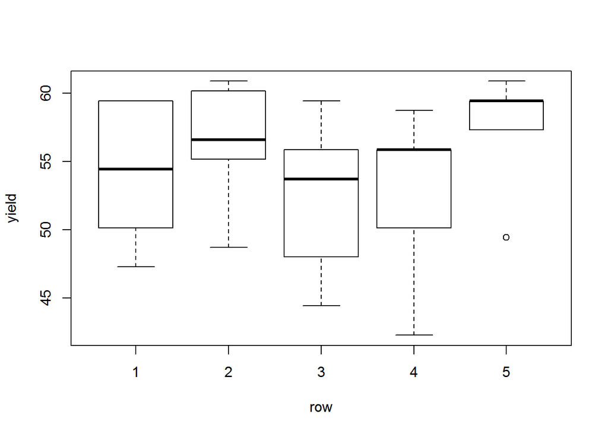

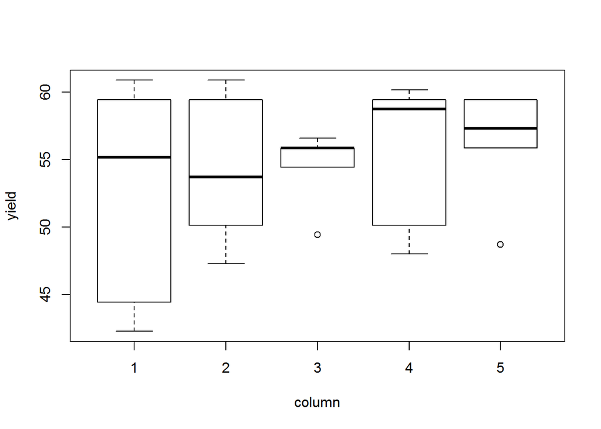

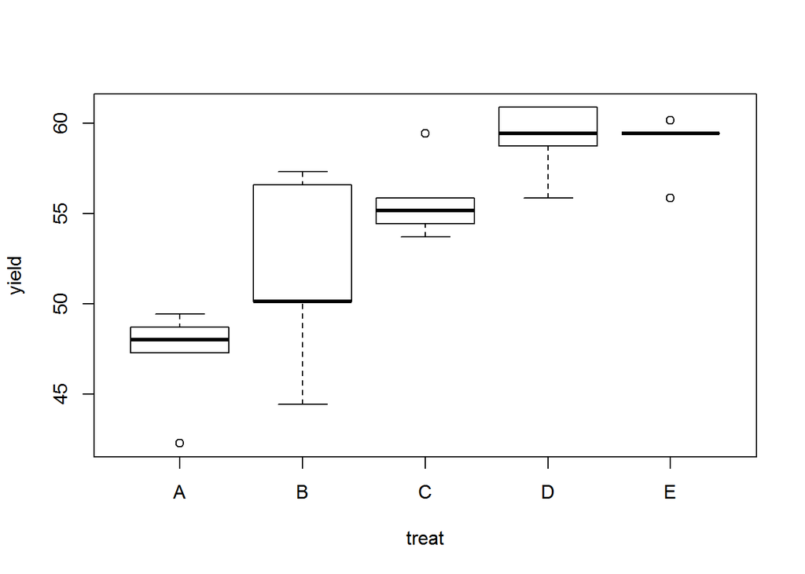

```r
plot(yield ~ row + column + treat)
```

*To see the treatment effects better, we want to adjust yield for the row and column effects. We can do this by fit a model with only row and column factors and plot the residuals against the treatment.*

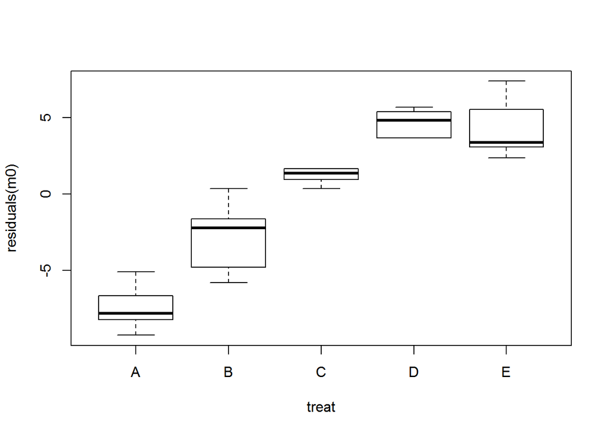

```r
m0 = lm(yield ~ row + column);
plot(residuals(m0) ~ treat)
```

## Fit a 3-way ANOVA model

```r
m = lm(yield ~ row + column + treat);
anova(m);
```

```
## Analysis of Variance Table
##
## Response: yield
##           Df Sum Sq Mean Sq F value    Pr(>F)
## row        4  99.20  24.801  5.2553    0.0111 *
## column     4  38.48   9.620  2.0385    0.1527
## treat      4 522.30 130.574 27.6685 5.619e-06 ***
## Residuals 12  56.63   4.719
## ---
## Signif. codes:  0 '***' 0.001 '**' 0.01 '*' 0.05 '.' 0.1 ' ' 1
```

There is strong treatment effect after adjusting for field row and column.

Tests for row or column effects may not be reliable.

## The cost of blocking (page 68)

## Relative efficiency

(Pages 286-287, Keuhl)

Extract MSE from the ANOVa table

```r
a = anova(m)
ms = a$`Mean Sq`;
mse = ms[4];
t = 5;
```

If we blocked only on rows, in a RCB design, the estimated mean sequare error is:
$$s^2_{rcb} = \dfrac{MS columns + (t-1) MSE}{t} = \dfrac{9.620206 + 4 \times 4.7192427}{5} = 5.6994353$$
and the relative effficiency is
$$RE_{col} = s^2_{rcb} / s^2_{ls} = 5.6994353/4.7192427 = 1.2077013.$$

## Inference on contrasts of treatment means

Same formula as before. See page 283 of Kuehl.